# Exploración dataset de usuarios

Librerias:

```r
library(plyr)
library(dplyr)
```

Se carga el dataset:

```r
users <- read.csv("dataset_modificado/dataset-usuarios.csv", encoding="UTF-8")
```

Primeras filas del dataset:

```r
head(users)
```

|  | App | Translated_Review | sentences_count | characters_count | sentiment_polarity_score | sentiment_polarity | sentiment_subjectivity_score | sentiment_subjectivity | spelling_quality_score | spelling_quality | ease_of_reading_score | ease_of_reading_quality | grammar_check_score |
| --- | --- | --- | --- | --- | --- | --- | --- | --- | --- | --- | --- | --- | --- |
| 1 | 10 Best Foods for You | I like eat delicious food. That's I'm cooking food myself, case "10 Best Foods" helps lot, also "Best Before (Shelf Life)" | 2 | 122 | 1.00 | Very positive | 0.5333333 | Objective/subjective | 0.875 | Bad | 86.20 | Easy | 5 |
| 2 | 10 Best Foods for You | This help eating healthy exercise regular basis | 1 | 47 | 0.25 | Pretty positive | 0.2884615 | Pretty objective | 1.000 | Very good | 38.99 | Difficult | 0 |
| 3 | 10 Best Foods for You | Works great especially going grocery store | 1 | 42 | 0.40 | Pretty positive | 0.8750000 | Quite subjective | 1.000 | Very good | 48.47 | Difficult | 0 |
| 4 | 10 Best Foods for You | Best idea us | 1 | 12 | 1.00 | Very positive | 0.3000000 | Pretty objective | 1.000 | Very good | 119.19 | Very Easy | 1 |
| 5 | 10 Best Foods for You | Best way | 1 | 8 | 1.00 | Very positive | 0.3000000 | Pretty objective | 1.000 | Very good | 120.21 | Very Easy | 0 |
| 6 | 10 Best Foods for You | Amazing | 1 | 7 | 0.60 | Pretty positive | 0.9000000 | Quite subjective | 1.000 | Very good | 36.62 | Difficult | 0 |

Tipo de cada dato:

```r
str(users[0,])
```

```
'data.frame':   0 obs. of  13 variables:
 $ App                         : chr
 $ Translated_Review           : chr
 $ sentences_count             : int
 $ characters_count            : int
 $ sentiment_polarity_score    : num
 $ sentiment_polarity          : chr
 $ sentiment_subjectivity_score: num
 $ sentiment_subjectivity      : chr
 $ spelling_quality_score      : num
 $ spelling_quality            : chr
 $ ease_of_reading_score       : num
 $ ease_of_reading_quality     : chr
 $ grammar_check_score         : int
```

Resumen de los datos

```r
summary(users)
```

```
     App            Translated_Review  sentences_count  characters_count sentiment_polarity_score
 Length:37427       Length:37427       Min.   : 1.000   Min.   :   2.0   Min.   :-1.0000
 Class :character   Class :character   1st Qu.: 1.000   1st Qu.:  33.0   1st Qu.: 0.0000
 Mode  :character   Mode  :character   Median : 2.000   Median :  86.0   Median : 0.1500
                                       Mean   : 2.632   Mean   : 113.2   Mean   : 0.1822
                                       3rd Qu.: 4.000   3rd Qu.: 165.0   3rd Qu.: 0.4000
                                       Max.   :27.000   Max.   :2713.0   Max.   : 1.0000
 sentiment_polarity sentiment_subjectivity_score sentiment_subjectivity spelling_quality_score
 Length:37427       Min.   :0.0000               Length:37427           Min.   :0.0000
 Class :character   1st Qu.:0.3571               Class :character       1st Qu.:0.8545
 Mode  :character   Median :0.5143               Mode  :character       Median :0.9180
                    Mean   :0.4928                                      Mean   :0.8930
                    3rd Qu.:0.6500                                      3rd Qu.:1.0000
                    Max.   :1.0000                                      Max.   :1.0000
 spelling_quality   ease_of_reading_score ease_of_reading_quality grammar_check_score
 Length:37427       Min.   :-1570.79      Length:37427            Min.   : 0.000
 Class :character   1st Qu.:   58.45      Class :character        1st Qu.: 0.000
 Mode  :character   Median :   74.53      Mode  :character        Median : 1.000
                    Mean   :   74.03                              Mean   : 1.452
                    3rd Qu.:   90.77                              3rd Qu.: 2.000
                    Max.   :  206.84                              Max.   :40.000
```

A continuación se muestra la frecuencia del tipo de opinión de la reseñas

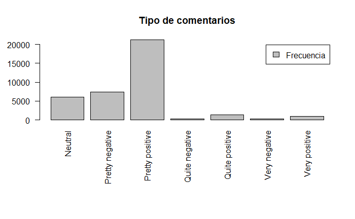

```r
opolarity <- users %>% plyr::count(c("sentiment_polarity"))
op <- par(mar = c(10,4,4,2) + 0.1) # Para que se vean los labels completos
barplot(opolarity$freq, names.arg=opolarity$sentiment_polarity, legend.text = "Frecuencia",las=2, main="Tipo de comentarios")
par(op) # Se reinicia el tamaño de la ventana
```

Se puede apreciar que la gente suele opinar más cuando le gusta una aplicación y los comentarios suelen ser ligeramente positivos. También es de notar que la mayoría de comentarios negativos muestran un ligero disgusto.

Veamos la objetividad de las opiniones

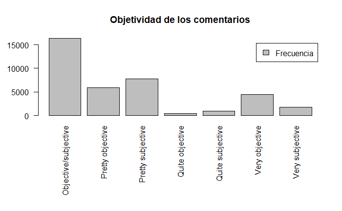

```r
osubjectivity <- users %>% plyr::count(c("sentiment_subjectivity"))
op <- par(mar = c(10,4,4,2) + 0.1) # Para que se vean los labels completos
barplot(osubjectivity$freq, names.arg=osubjectivity$sentiment_subjectivity, legend.text = "Frecuencia",las=2, main="Objetividad de los comentarios")
par(op) # Se reinicia el tamaño de la ventana
```

Veamos la calidad de redacción

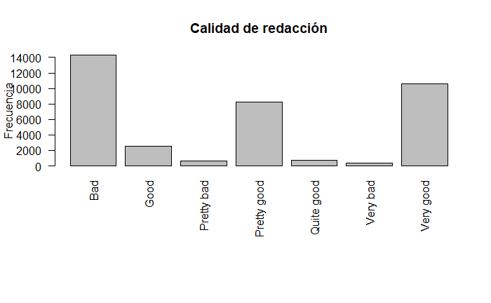

```r
ospelling <- users %>% plyr::count(c("spelling_quality"))
op <- par(mar = c(10,4,4,2) + 0.1) # Para que se vean los labels completos
barplot(ospelling$freq, names.arg=ospelling$spelling_quality, ylab="Frecuencia", las=2, main="Calidad de redacción")
par(op) # Se reinicia el tamaño de la ventana
```

Se puede apreciar que hay muchas reseñas cuya calidad de redacción es mala, aunque también es de notar que hay más reseñas bien redactadas que mal redactadas, pues hay una gran cantidad de reseñas bien y muy bien redactadas.

Revisemos ahora la facilidad de lectura

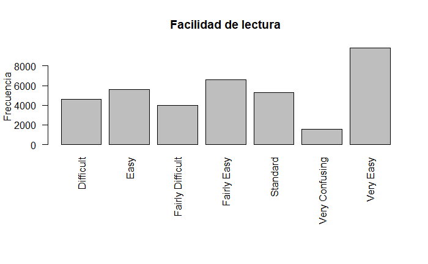

```r
oreading <- users %>% plyr :: count(c("ease_of_reading_quality"))
op <- par(mar = c(10,4,4,2) + 0.1) # Para que se vean los labels completos
barplot(oreading$freq, names.arg=oreading$ease_of_reading_quality, ylab="Frecuencia", las=2, main="Facilidad de lectura")
par(op) # Se reinicia el tamaño de la ventana
```

Se puede apreciar que en su mayoría las reseñas no son complicadas de entender.

Ahora estudiemos las variables numéricas

```r
numeric_atr <- users %>% dplyr::select(where(is.numeric))
head(numeric_atr)
```

|  | sentences_count | characters_count | sentiment_polarity_score | sentiment_subjectivity_score | spelling_quality_score | ease_of_reading_score | grammar_check_score |
| --- | --- | --- | --- | --- | --- | --- | --- |
| 1 | 2 | 122 | 1.00 | 0.5333333 | 0.875 | 86.20 | 5 |
| 2 | 1 | 47 | 0.25 | 0.2884615 | 1.000 | 38.99 | 0 |
| 3 | 1 | 42 | 0.40 | 0.8750000 | 1.000 | 48.47 | 0 |
| 4 | 1 | 12 | 1.00 | 0.3000000 | 1.000 | 119.19 | 1 |
| 5 | 1 | 8 | 1.00 | 0.3000000 | 1.000 | 120.21 | 0 |
| 6 | 1 | 7 | 0.60 | 0.9000000 | 1.000 | 36.62 | 0 |

Veamos si hay alguna correlación lineal entre ellas

```r
cor(numeric_atr)
```

```
                             sentences_count characters_count sentiment_polarity_score
sentences_count                   1.00000000       0.82228639              -0.13117839
characters_count                  0.82228639       1.00000000              -0.16166778
sentiment_polarity_score         -0.13117839      -0.16166778               1.00000000
sentiment_subjectivity_score      0.03642405       0.02322726               0.26158728
spelling_quality_score            0.07098561       0.05818119               0.01022385
ease_of_reading_score            -0.08410741      -0.22157195               0.09064556
grammar_check_score               0.45407041       0.58309298              -0.10476585
                             sentiment_subjectivity_score spelling_quality_score ease_of_reading_score
sentences_count                                0.03642405             0.07098561           -0.08410741
characters_count                               0.02322726             0.05818119           -0.22157195
sentiment_polarity_score                       0.26158728             0.01022385            0.09064556
sentiment_subjectivity_score                   1.00000000             0.06725789           -0.02131618
spelling_quality_score                         0.06725789             1.00000000            0.06658834
ease_of_reading_score                         -0.02131618             0.06658834            1.00000000
grammar_check_score                            0.00354557            -0.10232665           -0.12859421
                             grammar_check_score
sentences_count                       0.45407041
characters_count                      0.58309298
sentiment_polarity_score             -0.10476585
sentiment_subjectivity_score          0.00354557
spelling_quality_score               -0.10232665
ease_of_reading_score                -0.12859421
grammar_check_score                   1.00000000
```

Son de notar las siguientes relaciones lineales:

- sentences_count vs characters_count : 0.82228639
- grammar_check_score vs characters_count : 0.58309298
- grammar_check_score vs sentences_count : 0.45407041
- sentiment_polarity_score vs sentiment_subjectivity_score : 0.261587278 Relación lineal directa
- spelling_quality_score vs grammar_check_score :-0.102326653 Relación lineal inversa
- sentiment_polarity_score vs grammar_check_score: -0.104765855 Relación lineal inversa
- ease_of_reading_score vs grammar_check_score : -0.128594206 Relación lineal inversa
- sentiment_polarity_score vs characters_count: -0.16166778
- sentiment_polarity_score vs sentences_count : -0.13117839
- ease_of_reading_score vs characters_count : -0.22157195

- Tanto la facilidad de lectura como la calidad de escritura de los comentarios son inversamente proporcionales a los errores gramaticales, lo cuál tiene sentido, pues entre peor escritas estén las palabras, es menos probable que se pueda entender el mensaje.
- La polaridad es inversamente proporcional a los errores gramaticales, lo que podría indicar que mientras menos le agrade a un individuo una aplicación, tenderá a escribir su review (tal vez por el enojo)